# EddyFlux Check for Cold Air Drift

Adrienne

2023-09-18

Let’s see if we see cold air drift in our data.

Decided to use the mixing ratio because it seems to be the best way to compare across temperatures.

From the EddyPro manual- For closed path gas analyzers, data may be converted to mixing ratios. At this point in the raw data processing, metadata concerning gas concentrations from closed path systems are analyzed by EddyPro to autonomously decide whether to perform a sample-by-sample conversion into mixing ratios (r, moles of gas per mole of dry air). Expressing gas concentrations as mixing ratios is convenient because this makes it unnecessary to apply the WPL correction (Webb et al., 1980). It is an alternative way to account for air density fluctuations resulting from thermal expansion/contraction and concentration/dilution due to water vapor (see Ibrom et al., 2007b, for example). For a thorough discussion concerning the use of mixing ratios in closed path instruments, see Burba et al. (2012).

First let’s just look at September 6th 2023

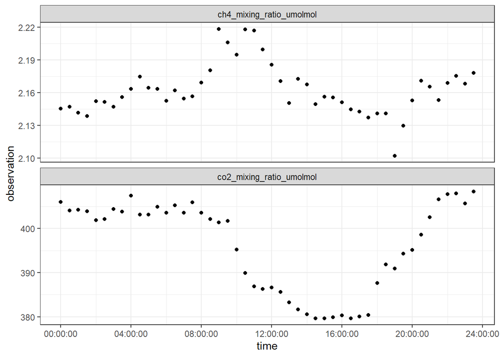

Now let’s look at the mixing ratio from September 5th - 12th, 2023

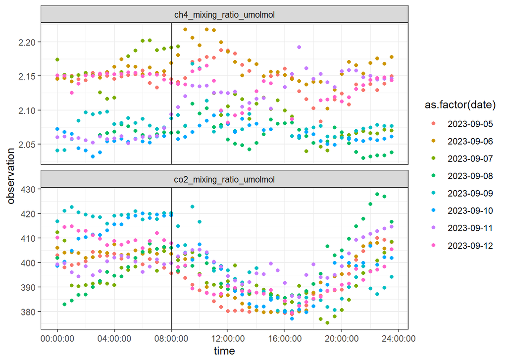

Let’s see what the wind and temperature looked like for that week

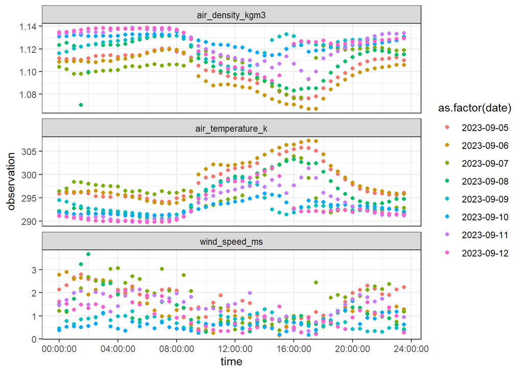

Let’s see what the fluxes look like from Sept 5- 12th, 2023

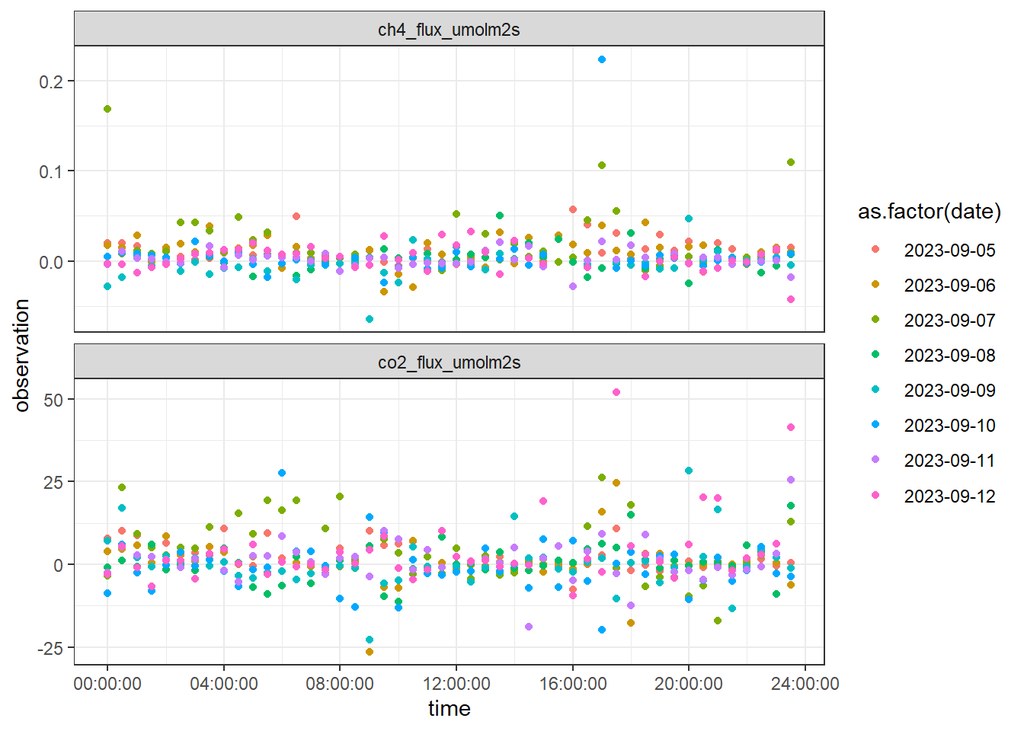

Let’s see what February looks like when there are no leaves on the tree

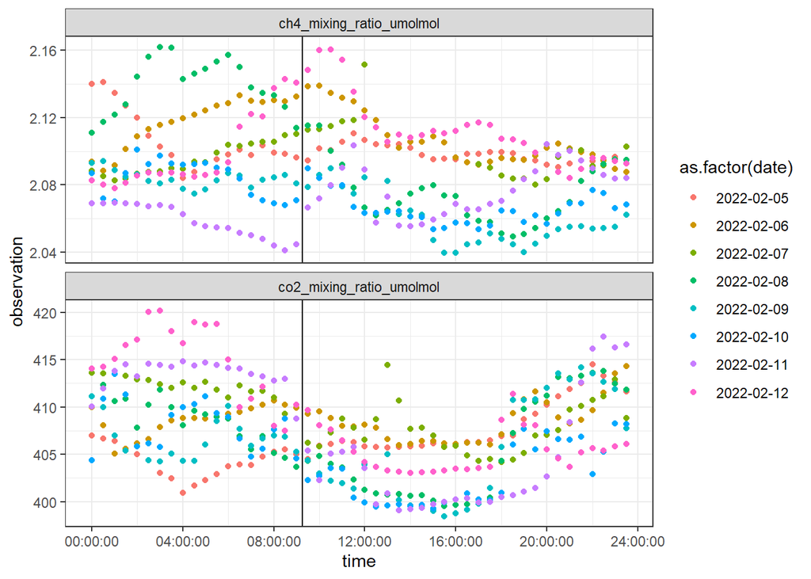

Let’s look at Air Temperature, Air density, and wind speed over the same time in February

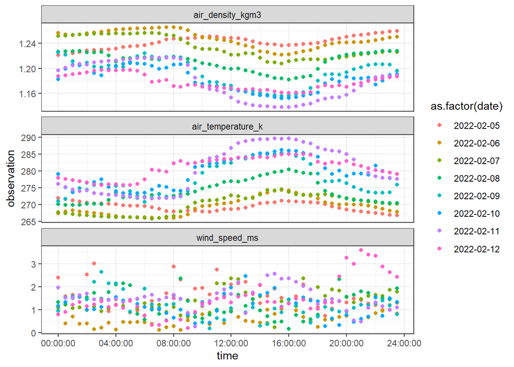

Let’s look at all the data averaged for each month to the 24 hour time steps for 2020-2023.

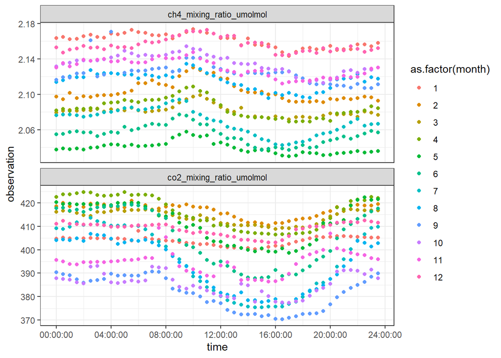

Let’s do the same thing for the weather variables

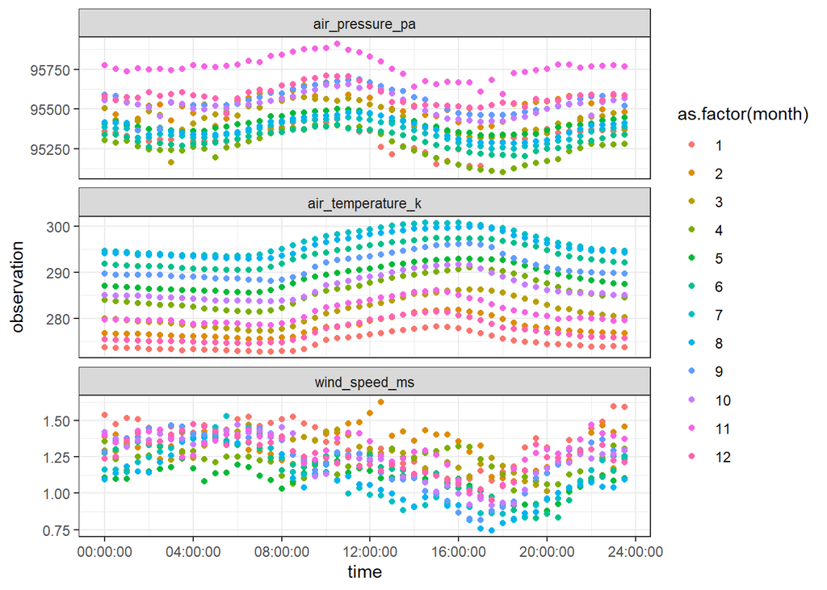

Let’s look at the timeseries of mixing ratio

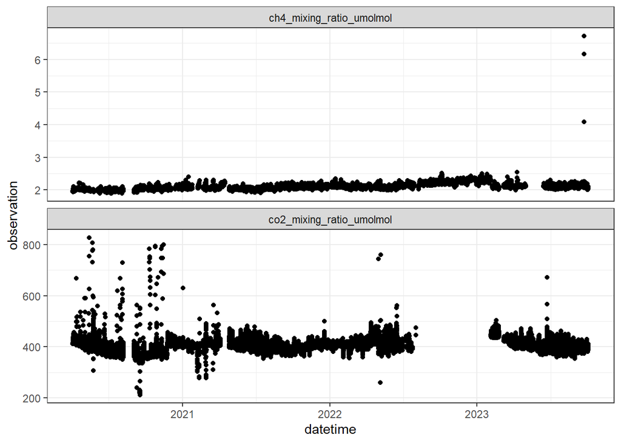

What is happening to the CH4 mixing ration in 2023?

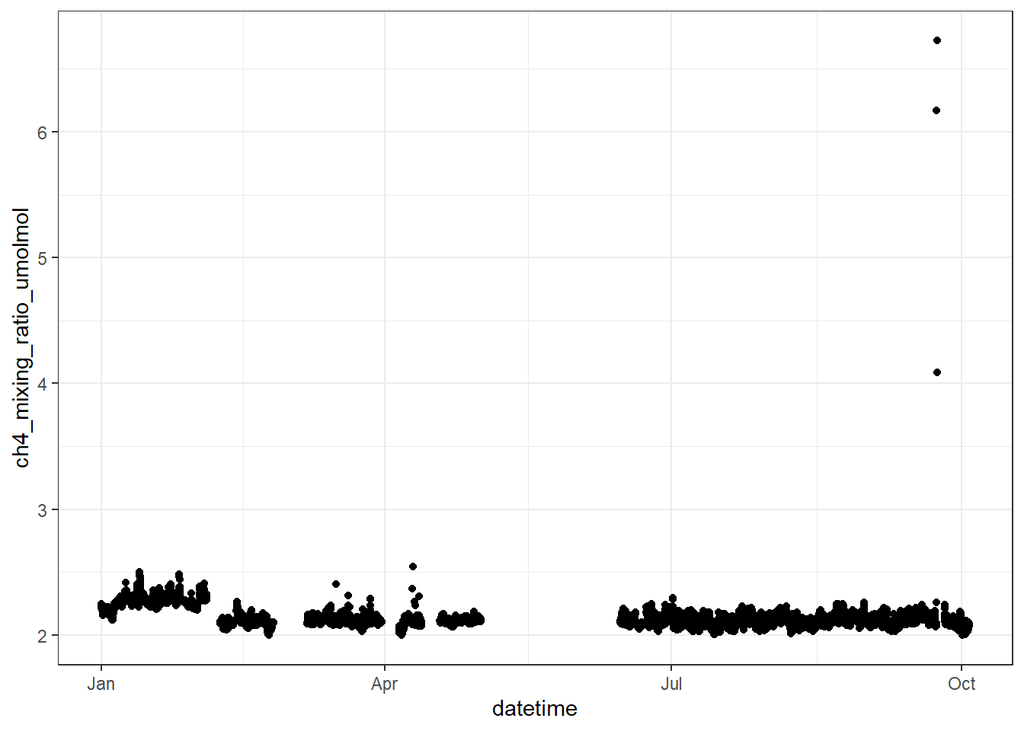